# CHL Status Summary: 2010-2018 [IV]

T.Hooker

13 August, 2019

```r
#options(table_counter=FALSE)
tidy_package <- c("plyr", "dplyr", "tidyr", "magrittr", "htmlTable")
if(!"tidyr" %in% (.packages())) {invisible(lapply(tidy_package, function(x) suppressMessages(library(x, character.only=T, quietly = T, warn.conflicts = F))))}
##
graph_package <- c("ggplot2", "scales")
if(!"ggplot2" %in% (.packages())) {invisible(lapply(graph_package, library, character.only=T, quietly = T, warn.conflicts = F))}
##
options(scipen = 999, digits = 4, stringsAsFactors = FALSE, keep.source = TRUE,
        width=75)
##
#startwork.date <- format(Sys.Date(), "%y%m%d")
knitr::opts_chunk$set(cache=TRUE)
```

## Notes

Prior work compared and compiled data from two (2) active files containing CHL data:

1. A file for the 2010-2016 CHL data and cleanup procedures, and
   - File :: “CHdat5_XX_4.0_190215_t1.xlsx”
2. A file for 2017-2018 CHL data based on the more recent UPHL-LIMS system and incorporating a new HPLC method for CHL analysis
   - File :: “CHL201718_CHL08_03_noDup_dat_190226_t1.xlsx”

Goals were to align dataset-fields, compare calculations, ensure completeness of project datasets, and prepare data for import to AWQMS. It is anticipated that much of this latter work will be performed on a project-specific basis.

[190310] :: New Notebook / Version to coninue Utah-Lake specific CHL cleanup, matchup and import to AWQMS.

- Continuing Work Elements

**Working Datasets**

1. UTLK CHL 2010 - 2016
   - Dataframe `utlk_CHL_201016_import01`
     - Note that some updates to XLS-datafile were made to complete import process
   - UTLK-specific Activity.IDs for Lake / Non-Lake records were compiled and cleaned
     - `awqms_ACTID_UTLK_raw_02`
   - Source dataframe for CHL results [2010-2016] :: `UL1016_09`
     - Only 370 records from dataframe were transferred to import file. Remaining records did not have a match to UTLK-specific ACT.IDs
   - XLS file for import to AWQMS :: `UTLK_CHL_201016_import01_190308_t1.xlsx`
2. UTLK CHL 2017 - 2018
   - `UL18718_05`

**Prior Work**

- Build from $3.4/ 3.41, but apply cleanup to more recent CHL data (2017-18)
- Completed CHL 2010-2016 UTAH LAKE import (sect. 3.5.2) from nb: `CHL_Compile_ALL_01_190306_v02.Rmd`
- Completed CHL 2017/2018 UTAH LAKE import (sect. 6.3) from nb: `CHL_Compile_ALL_02_190310_v01.Rmd`

[190417]

- Prior to splitting UTLK datasets, working dataframes were:
  - `CHL1016_01`
  - `CHL1718_01`
- These were saved as .rds files and need to be re-imported for this notebook
  - see `DF_recovery_190417.r`

[190715]

- Getting back to look at CHL data for the remaining records…
- Will extract WSpur data for Suzan T.
- **Information on WSpur project can be found in notebook “CHL_Status_ALL_03_190417_v01.Rmd”**

[190813]

- Re-starting CHL-status review
- ID cleanup needs
- fix and import datasets…

## 0.0 Project Notes

Goal: Review *completeness*-related status of CHL results from both datasets / data-periods and summarize for management review

### 0.1 Workspace cleanup

- tidy things up !
  - Backup workspace :: `190417.1.RData`
  - Cleaned up :: `190417-2.RData`

## 1.0 Working dataframes

### 1.1 Import CHL 2010-2016 RDS file

```r
# file.01  <- choose.files(caption="Select _working_ DATA file [*.RDS]", multi = FALSE)
# CHL1016_01b <- readRDS(file.01)
```

### 1.2 Import CHL 2017-2018 RDS file

```r
# file.02  <- choose.files(caption="Select _working_ DATA file [*.RDS]", multi = FALSE)
# CHL1718_01b <- readRDS(file.02)
```

### 1.3 Compare versions of dataframes

During setup of this notebook, and workspace cleanup, two prior working dataframes were kept, and two copies of these dataframes from previous notebooks were exported/re-imported via RDS; need to clarify whether these objects are the same, and if not, which one is more accurate or newer.

```r
# all(CHL1016_01 == CHL1016_01b,na.rm = T)
# all(CHL1718_01 == CHL1718_01b,na.rm = T)
# ##
# identical(CHL1016_01, CHL1016_01b)
# identical(CHL1718_01, CHL1718_01b)
```

- They look equivalent / identical
  - remove extraneous DFs

```r
# rm(CHL1016_01b, CHL1718_01b)
```

## 2.0 Status: CHL 2017/18

- Dataframe `CHL1718_01`
  - Rows :: 9226
  - Columns :: 82
  - Sample.Dates :: From 2016-08-15 to 2018-12-11
1. $Proj_Use levels by Project::

```r
CHL1718_01 %>% distinct(SKey2, .keep_all=T) %>% {addmargins(table(.$Trip_root, .$Proj_Use, useNA="ifany", deparse.level=2))} %>% htmlTable::htmlTable(., css.cell = rbind(rep("padding-left: 0.8em; padding-right: 0.8em;font-size: 0.75em;", times=ncol(.)+1), matrix("padding-left: 0.75em; padding-right: 0.75em; font-size: 0.75em;", ncol=ncol(.)+1, nrow=nrow(.))), align=c(""), caption="", total=T)
```

|  | .$Proj_Use UTLK | .$Proj_Use |  | Sum |
| --- | --- | --- | --- | --- |
| .$Trip_root |  |  |  |  |
| BORFG | 0 | 16 |  | 16 |
| BYUUL | 84 | 0 |  | 84 |
| GSLWET | 6 | 50 |  | 56 |
| HABS | 3 | 0 |  | 3 |
| JRULI | 138 | 71 |  | 209 |
| LAKES | 48 | 276 |  | 324 |
| UBI | 0 | 116 |  | 116 |
| UCASE | 3 | 156 |  | 159 |
| USGS | 0 | 8 |  | 8 |
| UTLK | 657 | 4 |  | 661 |
| WRI | 0 | 8 |  | 8 |
| WS | 0 | 8 |  | 8 |
| Sum | 939 | 713 |  | 1652 |

### 2.1 Verify records that were already imported for UTLK

- Import Import-data-file and review imported Activities
  - Could just import the Activities tab `Activities_imported`, but pulling the actual data that were imported [`dat03`] will result in a cleaner record comparison…

```r
# file.03  <- choose.files(caption="Select _working_ DATA file [*.XLSX]", multi = FALSE)
utlk_chl1718_imported <- openxlsx::read.xlsx(file.03,
                                             sheet="dat03", startRow = 1,
                                             rowNames=FALSE, check.names = T)
```

- File :: UTLK_CHL_201718_import02_190311_t2.xlsx
- Path :: U:/INFODATA/Sampling/Data_Cleanup_Scripts/190227_Full_CHL_results/CHL_ALL_compile_r
  - Records :: 1992
  - Columns :: 105
  - Sample.Dates :: From 2017-05-10 to 2018-12-11
2. Projects imported ::

   |  | ..Trip_root | Freq |
   | --- | --- | --- |
   | 1 | UTLK | 410 |
   | 2 | Sum | 410 |

- Update Proj_Use in `CHL1718_01` w/ verified imported records (based on SKey2)
  - Version datafile

```r
CHL1718_02 <- CHL1718_01
```

```r
CHL1718_02 %<>% mutate(Imported = as.character(NA)) %>% mutate(
    Imported = case_when(
        SKey2 %in% utlk_chl1718_imported$SKey2 ~ "utlk_01")) %>%
    select(Imported, everything())
```

```r
CHL1718_02 %>% {addmargins(table(.$Proj_Use, .$Imported, useNA="ifany", deparse.level = 2))}
```

```
          .$Imported
.$Proj_Use utlk_01 <NA>  Sum
      UTLK    3126 3008 6134
      <NA>       0 3092 3092
      Sum     3126 6100 9226
```

```r
CHL1718_02 %>% filter(Proj_Use == "UTLK" & Imported == "utlk_01") %>% distinct(SKey2, .keep_all=T) %>% {addmargins(table(.$Trip_root, useNA="ifany", deparse.level=2))} %>% as.data.frame(.) %>% htmlTable::htmlTable(., css.cell = rbind(rep("padding-left: 0.8em; padding-right: 0.8em;font-size: 0.75em;", times=ncol(.)+1), matrix("padding-left: 0.75em; padding-right: 0.75em; font-size: 0.75em;", ncol=ncol(.)+1, nrow=nrow(.))), align=c(""), caption="", total=T)
```

|  | ..Trip_root | Freq |
| --- | --- | --- |
| 1 | UTLK | 410 |
| 2 | Sum | 410 |

- The number of unique `SKey2` in CHL1718 data that match CHL1718 imported records is consistent with the imported set and number of Activtities imported
- Records with Proj_Use = `UTLK` and Imported != `utlk_01` appear to lack matches in the AWQMS chemistry data available
  - Less importance can now be placed on UTLK/utlk_01 -matched records, as these are already in AWQMS, the remainder need to be evaluated and prepared for import

**Projects (`Trip_root`) that can be ignored with respect to AWQMS import** ::

- HABS :: No field data available and not imported to AWQMS
- GSLWET :: Sites not in AWQMS
- Willard Spur (WSpur) :: Sites not in AWQMS
- UCASE-related records need to have WC vs. benthic samples clarified (and verified)

```r
# select(CHL1718_02, contains("status", ignore.case = T)) %>% names(.)
```

### 2.2 Records Available for matchup and AWQMS.import

```r
CHL1718_02 %>% {unique(.$Imported)}
```

```
[1] NA        "utlk_01"
```

```r
CHL1718_02 %>% {unique(.$Proj_Use)}
```

```
[1] NA     "UTLK"
```

```r
CHL1718_02 %>% {addmargins(table(.$Imported, .$Proj_Use,
                                 useNA="ifany", deparse.level = 2))}
```

```
          .$Proj_Use
.$Imported UTLK <NA>  Sum
   utlk_01 3126    0 3126
   <NA>    3008 3092 6100
   Sum     6134 3092 9226
```

- Annotate other project-group records in `Proj_Use`

```r
wetL_projGrp <- c("FRNG", "GSLWET", "IW", "REFWET", "WSpur", "WS")
utlk_projGrp <- c("BYUUL", "UTLK")
CHL1718_02 %>% {addmargins(table(.$Trip_root,
                                 useNA="ifany", deparse.level = 2))}
```

```
.$Trip_root
 BORFG  BYUUL GSLWET   HABS  JRULI  LAKES    UBI  UCASE   USGS   UTLK    WRI     WS    Sum
    93    420    233      9    627   1659    543    472     40   5042     24     64   9226
```

```r
#
CHL1718_02 %<>% mutate(
  Proj_Use = case_when(
    Trip_root %in% wetL_projGrp ~ "WetL",
    Trip_root %in% utlk_projGrp ~ "UTLK",
    !is.na(Proj_Use) ~ Proj_Use,
    TRUE ~ as.character(NA))
)
#
CHL1718_02 %>% {addmargins(table(.$Trip_root, .$Proj_Use,
                                 useNA="ifany", deparse.level = 2))}
```

```
           .$Proj_Use
.$Trip_root UTLK WetL <NA>  Sum
     BORFG     0    0   93   93
     BYUUL   420    0    0  420
     GSLWET    0  233    0  233
     HABS      9    0    0    9
     JRULI   414    0  213  627
     LAKES   237    0 1422 1659
     UBI       0    0  543  543
     UCASE     7    0  465  472
     USGS      0    0   40   40
     UTLK   5042    0    0 5042
     WRI       0    0   24   24
     WS        0   64    0   64
     Sum    6129  297 2800 9226
```

- Can also ignore `Imported` = `!is.na()`

### 2.3 Available Record Completeness

**Dataset elements to use as filters**:

1. Imported = `NULL`
- Some record-sets appear to be missing Volumes…

```r
CHL1718_02 %>%
  {addmargins(table(.$Trip_root, .$No_VOL,
                      useNA="ifany", deparse.level = 2))}
```

```
           .$No_VOL
.$Trip_root No_VOL <NA>  Sum
     BORFG       0   93   93
     BYUUL       0  420  420
     GSLWET      9  224  233
     HABS        9    0    9
     JRULI     186  441  627
     LAKES     224 1435 1659
     UBI       511   32  543
     UCASE      92  380  472
     USGS        0   40   40
     UTLK        0 5042 5042
     WRI         0   24   24
     WS          0   64   64
     Sum      1031 8195 9226
```

```r
CHL1718_02 %>% distinct(SKey2, No_VOL, .keep_all = T) %>%
  {addmargins(table(.$Trip_root, .$No_VOL,
                      useNA="ifany", deparse.level = 2))}
```

```
           .$No_VOL
.$Trip_root No_VOL <NA>  Sum
     BORFG       0   16   16
     BYUUL       0   84   84
     GSLWET      3   53   56
     HABS        3    0    3
     JRULI      62  147  209
     LAKES      64  260  324
     UBI       111    5  116
     UCASE      38  121  159
     USGS        0    8    8
     UTLK        0  661  661
     WRI         0    8    8
     WS          0    8    8
     Sum       281 1371 1652
```

2. No_VOL = `NULL`

```r
CHL1718_02 %>%
  filter(is.na(Imported)) %>%
  filter(is.na(No_VOL)) %>%
  {addmargins(table(.$Trip_root, grepl("U", .$R.Code),
                    useNA="ifany", deparse.level = 2,
                    dnn=c("Trip_Root", "ResCode=U")))}
```

```
         ResCode=U
Trip_Root FALSE TRUE  Sum
   BORFG     88    5   93
   BYUUL    384   36  420
   GSLWET   209   15  224
   JRULI    351   90  441
   LAKES    876  559 1435
   UBI       12   20   32
   UCASE    265  115  380
   USGS      40    0   40
   UTLK    1309  607 1916
   WRI       13   11   24
   WS        47   17   64
   Sum     3594 1475 5069
```

## 3.0 Status: CHL 2010-16

- Dataframe `CHL1016_01`
  - Rows :: 13942
  - Columns :: 75
  - Sample.Dates :: From 2010-01-19 to 2016-11-15
1. $Proj_Use levels by Project::

```r
CHL1016_01 %>% distinct(SK2_3, .keep_all=T) %>% {addmargins(table(.$Proj.Grp, .$Proj_Use, useNA="ifany", deparse.level=2))} %>% htmlTable::htmlTable(., css.cell = rbind(rep("padding-left: 0.8em; padding-right: 0.8em;font-size: 0.75em;", times=ncol(.)+1), matrix("padding-left: 0.75em; padding-right: 0.75em; font-size: 0.75em;", ncol=ncol(.)+1, nrow=nrow(.))), align=c(""), caption="", total=T)
```

|  | .$Proj_Use UTLK | .$Proj_Use |  | Sum |
| --- | --- | --- | --- | --- |
| .$Proj.Grp |  |  |  |  |
| BOR | 0 | 119 |  | 119 |
| BRI | 0 | 447 |  | 447 |
| CUWJ | 0 | 191 |  | 191 |
| FarmB | 0 | 3 |  | 3 |
| FRNG | 0 | 102 |  | 102 |
| GSLWET | 24 | 309 |  | 333 |
| HAB | 37 | 2 |  | 39 |
| IW | 0 | 122 |  | 122 |
| JRULI | 745 | 257 |  | 1002 |
| LAKES | 129 | 481 |  | 610 |
| NPS | 0 | 1 |  | 1 |
| REFWET | 0 | 33 |  | 33 |
| SBCI | 0 | 62 |  | 62 |
| TMDLLAKES | 116 | 289 |  | 405 |
| UBI | 0 | 2 |  | 2 |
| UCASE | 11 | 730 |  | 741 |
| unknown | 0 | 60 |  | 60 |
| USFS | 0 | 47 |  | 47 |
| UtahLK | 16 | 0 |  | 16 |
| WINTERLAKES | 0 | 26 |  | 26 |
| WLA | 10 | 146 |  | 156 |
| WRI | 0 | 240 |  | 240 |
| WSpur | 0 | 1110 |  | 1110 |
| WWTP | 2 | 985 |  | 987 |
| Sum | 1090 | 5764 |  | 6854 |

### 3.1 Verify records that were already imported for UTLK

```r
file.04  <- choose.files(caption="Select _working_ DATA file [*.XLSX]", multi = FALSE)
utlk_chl1016_imported <- openxlsx::read.xlsx(file.04,
                                             sheet="Sheet 1", startRow = 1,
                                             rowNames=FALSE, check.names = T)
```

- Update Proj_Use in `CHL1016_01` w/ verified imported records (based on SKey2)
  - Version datafile

```r
CHL1016_02 <- CHL1016_01
```

```r
CHL1016_02 %<>% mutate(Imported = as.character(NA)) %>% mutate(
    Imported = case_when(
        SK2_3 %in% utlk_chl1016_imported$SKey2 ~ "utlk_01")) %>%
    select(Imported, everything())
```

```r
CHL1016_02 %>% {addmargins(table(.$Proj_Use, .$Imported, useNA="ifany", deparse.level = 2))}
```

```
          .$Imported
.$Proj_Use utlk_01  <NA>   Sum
      UTLK     372  1202  1574
      <NA>       0 12368 12368
      Sum      372 13570 13942
```

```r
CHL1016_02 %>% filter(Proj_Use == "UTLK" & Imported == "utlk_01") %>% distinct(SK2_3, .keep_all=T) %>% {addmargins(table(.$Proj.Grp, useNA="ifany", deparse.level=2))} %>% as.data.frame(.) %>% htmlTable::htmlTable(., css.cell = rbind(rep("padding-left: 0.8em; padding-right: 0.8em;font-size: 0.75em;", times=ncol(.)+1), matrix("padding-left: 0.75em; padding-right: 0.75em; font-size: 0.75em;", ncol=ncol(.)+1, nrow=nrow(.))), align=c(""), caption="", total=T)
```

|  | ..Proj.Grp | Freq |
| --- | --- | --- |
| 1 | JRULI | 32 |
| 2 | LAKES | 52 |
| 3 | TMDLLAKES | 72 |
| 4 | UtahLK | 6 |
| 5 | WLA | 9 |
| 6 | WWTP | 1 |
| 7 | Sum | 172 |

- The number of unique `SK2_3` in CHL1016_02 data that match CHL1016 imported records is consistent with the imported set and number of Activtities imported

### 3.2 Records Available for matchup and AWQMS.import

```r
CHL1016_02 %>% {unique(.$Imported)}
```

```
[1] NA        "utlk_01"
```

```r
CHL1016_02 %>% {unique(.$Proj_Use)}
```

```
[1] NA     "UTLK"
```

```r
CHL1016_02 %>% {addmargins(table(.$Imported, .$Proj_Use,
                                 useNA="ifany", deparse.level = 2))}
```

```
          .$Proj_Use
.$Imported  UTLK  <NA>   Sum
   utlk_01   372     0   372
   <NA>     1202 12368 13570
   Sum      1574 12368 13942
```

- Annotate other project-group recrods in Proj_USe

```r
wetL_projGrp <- c("FRNG", "GSLWET", "IW", "REFWET", "WSpur", "WS", "FarmB")
utlk_projGrp <- c("BYUUL", "UTLK")

CHL1016_02 %>% {addmargins(table(.$Proj.Grp,
                                 useNA="ifany", deparse.level = 2))}
```

```
.$Proj.Grp
        BOR         BRI        CUWJ       FarmB        FRNG      GSLWET         HAB          IW       JRULI
        279        2195         368           9         306         333         117         123        1008
      LAKES         NPS      REFWET        SBCI   TMDLLAKES         UBI       UCASE     unknown        USFS
       1513           3          99         186         774           4        2094         106          47
     UtahLK WINTERLAKES         WLA         WRI       WSpur        WWTP         Sum
         42          28         326         720        2195        1067       13942
```

```r
CHL1016_02 %<>% mutate(
  Proj_Use = case_when(
    Proj.Grp %in% wetL_projGrp ~ "WetL",
    Proj.Grp %in% utlk_projGrp ~ "UTLK",
    !is.na(Proj_Use) ~ Proj_Use,
    TRUE ~ as.character(NA))
)
#
CHL1016_02 %>% {addmargins(table(.$Proj.Grp, .$Proj_Use,
                                 useNA="ifany", deparse.level = 2))}
```

```
             .$Proj_Use
.$Proj.Grp     UTLK  WetL  <NA>   Sum
  BOR             0     0   279   279
  BRI             0     0  2195  2195
  CUWJ            0     0   368   368
  FarmB           0     9     0     9
  FRNG            0   306     0   306
  GSLWET          0   333     0   333
  HAB           111     0     6   117
  IW              0   123     0   123
  JRULI         747     0   261  1008
  LAKES         350     0  1163  1513
  NPS             0     0     3     3
  REFWET          0    99     0    99
  SBCI            0     0   186   186
  TMDLLAKES     232     0   542   774
  UBI             0     0     4     4
  UCASE          36     0  2058  2094
  unknown         0     0   106   106
  USFS            0     0    47    47
  UtahLK         42     0     0    42
  WINTERLAKES     0     0    28    28
  WLA            26     0   300   326
  WRI             0     0   720   720
  WSpur           0  2195     0  2195
  WWTP            6     0  1061  1067
  Sum          1550  3065  9327 13942
```

### 3.3 Available Records Completeness

1. `Imported` = `NULL`

```r
CHL1016_02 %>%
  filter(is.na(Imported)) %>%
  {addmargins(table(.$Proj.Grp, is.na(.$Filt.Vol),
                    useNA="ifany",
                    deparse.level = 2,
                    dnn=c("Proj.Grp", "Vol_missing?")))}
```

```
             Vol_missing?
Proj.Grp      FALSE  TRUE   Sum
  BOR           273     6   279
  BRI          2032   163  2195
  CUWJ           88   280   368
  FarmB           0     9     9
  FRNG           90   216   306
  GSLWET         42   291   333
  HAB            84    33   117
  IW            123     0   123
  JRULI         656   320   976
  LAKES        1255   102  1357
  NPS             0     3     3
  REFWET         99     0    99
  SBCI          183     3   186
  TMDLLAKES     501   135   636
  UBI             0     4     4
  UCASE        1662   432  2094
  unknown        48    58   106
  USFS            0    47    47
  UtahLK         15     9    24
  WINTERLAKES    19     9    28
  WLA           266    35   301
  WRI             0   720   720
  WSpur        1773   422  2195
  WWTP          136   928  1064
  Sum          9345  4225 13570
```

## 4.0 Identify Minimum-Required-Fields for data-import

- file :: `"uphl_LIMS_importconfig_Template_02_190813.xlsx"`
- path :: `"U:\INFODATA\Sampling\Data_Cleanup_Scripts\190227_Full_CHL_results\CHL_awqms_import_Template"`

```r
# importConfig_minFields <- readClipboard()
importConfig_minFields
```

```
 [1] "RESULT_status" "CCode"         "AgCode"        "ACT.Type"      "ACT.ID"        "SampNum"
 [7] "MLID_x"        "SDate_x"       "STime"         "SampType_x"    "CoC"           "AWQMS.Key"
[13] "Prob.Iden"     "R.Code"        "RValue_x"      "RVal_unit"     "LRL_x"         "LRL.unit"
[19] "MDL_x"         "MDL.unit"      "DFactor"       "Batch.Num"     "ADate"         "Act.Comment"
[25] "Res.Comment"
```

## Work Backwards on CHL-data completion / cleanup

## 5.0 Non-detects for measured CHL values

- How many Non-detects are there, by project, and how does this proportion change over time ?

### 5.1 2017-2018 CHL-values

- var-cleanup

```r
CHL1718_02 %<>% select(-Imported, -Proj_Use, -Trip.ID, -SKey1, -Activity.Comment, -Note,
                       -SITE_status, -Personnel.1, -Personnel.2, everything()) %>%
  select(Project.Name:MLID_x, QC_type, everything())
```

```r
CHL1718_02 %>%
  {addmargins(table(.$Trip_root, grepl("U", .$R.Code),
                    useNA = "ifany", deparse.level = 2,
                    dnn=c("Trip_root", "RCode_contains_U")))}
```

```
         RCode_contains_U
Trip_root FALSE TRUE  Sum
   BORFG     88    5   93
   BYUUL    384   36  420
   GSLWET   213   20  233
   HABS       7    2    9
   JRULI    453  174  627
   LAKES    997  662 1659
   UBI      265  278  543
   UCASE    321  151  472
   USGS      40    0   40
   UTLK    3947 1095 5042
   WRI       13   11   24
   WS        47   17   64
   Sum     6775 2451 9226
```

```r
CHL1718_02 %>%
  filter(!Method.ID %in% c("10300C")) %>%
  filter(ParamX %in% c("CHL.tot", "CHLA")) %>%
  {addmargins(table(.$Trip_root, grepl("U", .$R.Code),
         useNA="ifany", deparse.level = 2))}
```

```
           grepl("U", .$R.Code)
.$Trip_root FALSE TRUE  Sum
     BORFG     38    3   41
     BYUUL     84    0   84
     GSLWET   122    6  128
     HABS       6    0    6
     JRULI    338   80  418
     LAKES    625  197  822
     UBI      189  136  325
     UCASE    213   62  275
     USGS       8    0    8
     UTLK    1663  260 1923
     WRI       11    5   16
     WS        18    6   24
     Sum     3315  755 4070
```

- Number of non-detects (“U”) per year by Trip_root (by param)

```r
# project by PARAMs
CHL1718_02 %>%
  filter(!Method.ID %in% c("10300C")) %>%
  filter(ParamX %in% c("CHL.tot", "CHLA")) %>%
  {addmargins(table(.$Trip_root,
                    paste(toupper(.$Method.GRP),
                          .$ParamX,
                          sep="_"),
                    useNA="ifany", deparse.level = 2))}
```

```
           paste(toupper(.$Method.GRP), .$ParamX, sep = "_")
.$Trip_root CHL_CHL.tot CHL_CHLA CHL_HPLC_CHLA  Sum
     BORFG           16       16             9   41
     BYUUL            0        0            84   84
     GSLWET          56       56            16  128
     HABS             3        3             0    6
     JRULI          209      209             0  418
     LAKES          324      324           174  822
     UBI            116      116            93  325
     UCASE          120      120            35  275
     USGS             0        0             8    8
     UTLK           652      652           619 1923
     WRI              8        8             0   16
     WS               8        8             8   24
     Sum           1512     1512          1046 4070
```

- Building off ParamX == “CHLA” only

```r
CHL1718_02 %>%
  filter(!Method.ID %in% c("10300C")) %>%
  filter(ParamX %in% c("CHLA")) %>%
  group_by(Trip_root, Method.GRP) %>%
  summarise(.,
            n_obs=n(),
            n_NonDet= sum(stringr::str_detect(R.Code, "U"), na.rm=T),
            k_SKey2=n_distinct(SKey2, na.rm=T)) %>%
  mutate(p_NonDet = sprintf("%.f%%",(n_NonDet/n_obs)*100)) %>%
  select(-k_SKey2, everything()) %>%
  as.data.frame() %>%
  add_row(., Trip_root = "SUM",
          n_obs=sum(.$n_obs, na.rm=T),
          n_NonDet=sum(.$n_NonDet, na.rm=T)) %>%
  htmlTable::htmlTable(., css.cell = rbind(rep("padding-left: 0.75em; padding-right: 0.75em;font-size: 0.75em;", times=ncol(.)+1), matrix("padding-left: 0.75em; padding-right: 0.75em; font-size: 0.75em;", ncol=ncol(.)+1, nrow=nrow(.))), align=c("rll|ccr|c"), caption="", total=T, n.tspanner=c(2,1,2,1,1,2,2,2,1,2,1,2,1), tspanner=c("","", "", "", "", "", "", "", "", "", "", "", ""))
```

|  | Trip_root | Method.GRP | n_obs | n_NonDet | p_NonDet | k_SKey2 |
| --- | --- | --- | --- | --- | --- | --- |
| 1 | BORFG | CHL | 16 | 3 | 19% | 16 |
| 2 | BORFG | CHL_hplc | 9 | 0 | 0% | 9 |
| 3 | BYUUL | CHL_hplc | 84 | 0 | 0% | 84 |
| 4 | GSLWET | CHL | 56 | 5 | 9% | 56 |
| 5 | GSLWET | CHL_hplc | 16 | 0 | 0% | 16 |
| 6 | HABS | CHL | 3 | 0 | 0% | 3 |
| 7 | JRULI | CHL | 209 | 56 | 27% | 209 |
| 8 | LAKES | CHL | 324 | 129 | 40% | 324 |
| 9 | LAKES | CHL_hplc | 174 | 14 | 8% | 174 |
| 10 | UBI | CHL | 116 | 83 | 72% | 116 |
| 11 | UBI | CHL_hplc | 93 | 16 | 17% | 93 |
| 12 | UCASE | CHL | 120 | 44 | 37% | 120 |
| 13 | UCASE | CHL_hplc | 35 | 3 | 9% | 35 |
| 14 | USGS | CHL_hplc | 8 | 0 | 0% | 8 |
| 15 | UTLK | CHL | 652 | 149 | 23% | 652 |
| 16 | UTLK | CHL_hplc | 619 | 47 | 8% | 619 |
| 17 | WRI | CHL | 8 | 5 | 62% | 8 |
| 18 | WS | CHL | 8 | 2 | 25% | 8 |
| 19 | WS | CHL_hplc | 8 | 2 | 25% | 8 |
| 20 | SUM |  | 2558 | 558 |  |  |

```r
CHL1718_02 %>% mutate(
  Samp_WYqtr = case_when(
    lubridate::month(.$SDate_x) > 9 ~
      paste(lubridate::year(.$SDate_x)+1, ".q",
            sprintf("%.2i", lubridate::quarter(.$SDate_x, with_year = F,
                                               fiscal_start = 10)), sep=""),
    TRUE ~ paste(lubridate::year(.$SDate_x),".q",
                 sprintf("%.2i",lubridate::quarter(.$SDate_x, with_year=F,
                                                   fiscal_start=10)),sep=""))) %>%
  filter(Method.ID %in% c("10200H")) %>%
  filter(ParamX %in% c("CHLA")) %>%
  filter(grepl("U", .$R.Code)) %>%
  {addmargins(table(.$Trip_root, .$Samp_WYqtr,
                    useNA="ifany", deparse.level = 2),c(1,2))}
```

```
           .$Samp_WYqtr
.$Trip_root 2016.q04 2017.q03 2017.q04 2018.q01 2018.q02 2018.q03 2018.q04 2019.q01 Sum
     BORFG         0        3        0        0        0        0        0        0   3
     GSLWET        0        0        1        0        0        2        2        0   5
     JRULI         0        0        0        0        0       22       34        0  56
     LAKES         0       27       39       12        0       26       22        3 129
     UBI           0       36       47        0        0        0        0        0  83
     UCASE        17        5        0       12        0        2        4        4  44
     UTLK          0       20       26       25        8       22       16       32 149
     WRI           5        0        0        0        0        0        0        0   5
     WS            0        0        1        0        0        0        1        0   2
     Sum          22       91      114       49        8       74       79       39 476
```

```r
# CHLA records :: Percent of records w/ NonDetect by Method.Grp
CHL1718_02 %>% mutate(
  Samp_WYqtr = case_when(
    lubridate::month(.$SDate_x) > 9 ~
      paste(lubridate::year(.$SDate_x)+1, ".q",
            sprintf("%.2i", lubridate::quarter(.$SDate_x, with_year = F,
                                               fiscal_start = 10)), sep=""),
    TRUE ~ paste(lubridate::year(.$SDate_x),".q",
                 sprintf("%.2i",lubridate::quarter(.$SDate_x, with_year=F,
                                                   fiscal_start=10)),sep=""))) %>%
  group_by(Method.GRP, Trip_root, Samp_WYqtr) %>%
  # filter(stringr::str_detect(Method.ID, "HPLC",)) %>%
  filter(ParamX %in% c("CHLA")) %>%
  summarise(.,
            n_obs=n(),
            n_NonDet=sum(stringr::str_detect(R.Code, "U"), na.rm=T)) %>%
  mutate(p_NonDetect = sprintf("%.f%%", (n_NonDet/n_obs)*100)) %>%
  select(Trip_root, Method.GRP, Samp_WYqtr, p_NonDetect) %>%
  spread(Samp_WYqtr, p_NonDetect, drop=F) %>%
  htmlTable::htmlTable(., css.cell = rbind(rep("padding-left: 0.75em; padding-right: 0.75em;font-size: 0.75em;", times=ncol(.)+1), matrix("padding-left: 0.75em; padding-right: 0.75em; font-size: 0.75em;", ncol=ncol(.)+1, nrow=nrow(.))), align=c("rll|c|ccc|cccc|c"), caption="", total=F, n.tspanner=rep(2,length(unique(.$Trip_root))), tspanner=rep("",length(unique(.$Trip_root))))
```

|  | Trip_root | Method.GRP | 2016.q04 | 2017.q01 | 2017.q03 | 2017.q04 | 2018.q01 | 2018.q02 | 2018.q03 | 2018.q04 | 2019.q01 |
| --- | --- | --- | --- | --- | --- | --- | --- | --- | --- | --- | --- |
| 1 | BORFG | CHL |  |  | 38% | 0% |  |  |  |  |  |
| 2 | BORFG | CHL_hplc |  |  | 0% | 0% |  |  |  |  |  |
| 3 | BYUUL | CHL |  |  |  |  |  |  |  |  |  |
| 4 | BYUUL | CHL_hplc |  |  |  | 0% | 0% |  |  |  |  |
| 5 | GSLWET | CHL |  |  |  | 6% |  |  | 6% | 33% |  |
| 6 | GSLWET | CHL_hplc |  |  |  | 0% |  |  |  |  |  |
| 7 | HABS | CHL |  | 0% |  |  |  |  |  |  |  |
| 8 | HABS | CHL_hplc |  |  |  |  |  |  |  |  |  |
| 9 | JRULI | CHL |  |  |  |  |  |  | 27% | 27% |  |
| 10 | JRULI | CHL_hplc |  |  |  |  |  |  |  |  |  |
| 11 | LAKES | CHL |  |  | 31% | 42% | 46% |  | 57% | 32% | 60% |
| 12 | LAKES | CHL_hplc |  |  | 8% | 9% | 4% |  |  |  |  |
| 13 | UBI | CHL |  |  | 78% | 67% |  |  |  |  |  |
| 14 | UBI | CHL_hplc |  |  | 8% | 21% |  |  |  |  |  |
| 15 | UCASE | CHL | 34% |  | 36% |  | 50% |  | 29% | 36% | 29% |
| 16 | UCASE | CHL_hplc |  |  | 0% |  | 12% |  |  |  |  |
| 17 | USGS | CHL |  |  |  |  |  |  |  |  |  |
| 18 | USGS | CHL_hplc |  |  |  |  |  |  |  | 0% |  |
| 19 | UTLK | CHL |  |  | 22% | 16% | 22% | 22% | 28% | 18% | 39% |
| 20 | UTLK | CHL_hplc |  |  | 3% | 4% | 8% | 8% | 11% | 10% | 10% |
| 21 | WRI | CHL | 62% |  |  |  |  |  |  |  |  |
| 22 | WRI | CHL_hplc |  |  |  |  |  |  |  |  |  |
| 23 | WS | CHL |  |  |  | 25% |  |  |  | 25% |  |
| 24 | WS | CHL_hplc |  |  |  | 25% |  |  |  | 25% |  |

```r
# CHLA records :: Percent of records w/ NonDetect by Method.Grp
CHL1718_02 %>% mutate(
  Samp_WYqtr = case_when(
    lubridate::month(.$SDate_x) > 9 ~
      paste(lubridate::year(.$SDate_x)+1, ".q",
            sprintf("%.2i", lubridate::quarter(.$SDate_x, with_year = F,
                                               fiscal_start = 10)), sep=""),
    TRUE ~ paste(lubridate::year(.$SDate_x),".q",
                 sprintf("%.2i",lubridate::quarter(.$SDate_x, with_year=F,
                                                   fiscal_start=10)),sep=""))) %>%
  group_by(Method.GRP, Samp_WYqtr) %>%
  # filter(stringr::str_detect(Method.ID, "HPLC",)) %>%
  filter(ParamX %in% c("CHLA")) %>%
  summarise(.,
            n_obs=n(),
            n_NonDet=sum(stringr::str_detect(R.Code, "U"), na.rm=T)) %>%
  mutate(p_NonDetect = sprintf("%.f%%", (n_NonDet/n_obs)*100)) %>%
  select(Method.GRP, Samp_WYqtr, p_NonDetect) %>%
  spread(Samp_WYqtr, p_NonDetect, drop=F) %>%
  htmlTable::htmlTable(., css.cell = rbind(rep("padding-left: 0.75em; padding-right: 0.75em;font-size: 0.75em;", times=ncol(.)+1), matrix("padding-left: 0.75em; padding-right: 0.75em; font-size: 0.75em;", ncol=ncol(.)+1, nrow=nrow(.))), align=c("rll|c|ccc|cccc|c"), caption="", total=F)
```

|  | Method.GRP | 2016.q04 | 2017.q01 | 2017.q03 | 2017.q04 | 2018.q01 | 2018.q02 | 2018.q03 | 2018.q04 | 2019.q01 |
| --- | --- | --- | --- | --- | --- | --- | --- | --- | --- | --- |
| 1 | CHL | 38% | 0% | 37% | 33% | 30% | 22% | 30% | 26% | 39% |
| 2 | CHL_hplc |  |  | 6% | 7% | 8% | 8% | 11% | 10% | 10% |

### 5.2 2010-2016 CHL-values

- var cleanup

```r
CHL1016_02 %<>% select(-Imported, -Proj_Use, everything())
```

```r
CHL1016_02 %>%
  {addmargins(table(.$Proj.Grp, grepl("U", .$Non_Detect),
                    useNA = "ifany", deparse.level = 2,
                    dnn=c("Proj_grp", "RCode_contains_U")))}
```

```
             RCode_contains_U
Proj_grp      FALSE  TRUE   Sum
  BOR           134   145   279
  BRI           269  1926  2195
  CUWJ          252   116   368
  FarmB           9     0     9
  FRNG          121   185   306
  GSLWET        301    32   333
  HAB            75    42   117
  IW             78    45   123
  JRULI         774   234  1008
  LAKES         493  1020  1513
  NPS             3     0     3
  REFWET          8    91    99
  SBCI           26   160   186
  TMDLLAKES     388   386   774
  UBI             4     0     4
  UCASE        1203   891  2094
  unknown        61    45   106
  USFS           42     5    47
  UtahLK         34     8    42
  WINTERLAKES    27     1    28
  WLA           107   219   326
  WRI           244   476   720
  WSpur        1361   834  2195
  WWTP          979    88  1067
  Sum          6993  6949 13942
```

```r
CHL1016_02 %>% {addmargins(table(.$PARAM.X))}
```

```
 CHLA.aa CHLA.tot   CHLA.X     CHLB     PERI     PHEO      Sum
    2938     2639     4599       49      701     3016    13942
```

```r
CHL1016_02 %>%
  filter(!MethodID2 %in% c("10300C")) %>%
  filter(PARAM.X %in% c("CHL.tot", "CHLA", "CHLA.tot", "CHLA.X", "CHLA.aa")) %>%
  {addmargins(table(.$Proj.Grp, grepl("U", .$Non_Detect),
         useNA="ifany", deparse.level = 2))}
```

```
             grepl("U", .$Non_Detect)
.$Proj.Grp    FALSE  TRUE   Sum
  BOR           124    87   211
  BRI           259  1060  1319
  CUWJ          216     4   220
  FarmB           6     0     6
  FRNG          108    96   204
  GSLWET        301    32   333
  HAB            72     6    78
  IW             78    45   123
  JRULI         774   234  1008
  LAKES         468   624  1092
  NPS             2     0     2
  REFWET          8    58    66
  SBCI           26    98   124
  TMDLLAKES     384   262   646
  UBI             2     0     2
  UCASE         695   488  1183
  unknown        52    26    78
  USFS           42     5    47
  UtahLK         34     3    37
  WINTERLAKES    27     1    28
  WLA            98   143   241
  WRI           211   269   480
  WSpur        1037   567  1604
  WWTP          956    88  1044
  Sum          5980  4196 10176
```

```r
CHL1016_02 %>%
  {addmargins(table(.$PARAM.X, .$MethodID2,
                    useNA="ifany", deparse.level = 2))}
```

```
          .$MethodID2
.$PARAM.X  10200 10300 447.0   Sum
  CHLA.aa   2938     0     0  2938
  CHLA.tot  2639     0     0  2639
  CHLA.X    4500     0    99  4599
  CHLB         0     0    49    49
  PERI         0   701     0   701
  PHEO      2917     0    99  3016
  Sum      12994   701   247 13942
```

- Ignore PERI for now, keep EPA447.0

```r
CHL1016_02 %>%
  filter(!MethodID2 %in% c("10300C")) %>%
  filter(PARAM.X %in% c("CHL.tot", "CHLA", "CHLA.tot", "CHLA.X", "CHLA.aa")) %>%
  group_by(Proj.Grp, MethodID2) %>%
  summarise(.,
            n_obs=n(),
            n_NonDet= sum(stringr::str_detect(Non_Detect, "U"), na.rm=T),
            k_SKey2=n_distinct(SK2_3, na.rm=T)) %>%
  mutate(p_NonDet = sprintf("%.f%%",(n_NonDet/n_obs)*100)) %>%
  select(-k_SKey2, everything()) %>%
  as.data.frame() %>%
  add_row(., Proj.Grp = "SUM",
          n_obs=sum(.$n_obs, na.rm=T),
          n_NonDet=sum(.$n_NonDet, na.rm=T)) %>%
  htmlTable::htmlTable(., css.cell = rbind(rep("padding-left: 0.75em; padding-right: 0.75em;font-size: 0.75em;", times=ncol(.)+1), matrix("padding-left: 0.75em; padding-right: 0.75em; font-size: 0.75em;", ncol=ncol(.)+1, nrow=nrow(.))), align=c("rll|ccr|c"), caption="", total=T)
```

|  | Proj.Grp | MethodID2 | n_obs | n_NonDet | p_NonDet | k_SKey2 |
| --- | --- | --- | --- | --- | --- | --- |
| 1 | BOR | 10200 | 211 | 87 | 41% | 119 |
| 2 | BRI | 10200 | 1319 | 1060 | 80% | 447 |
| 3 | CUWJ | 10200 | 121 | 4 | 3% | 92 |
| 4 | CUWJ | 447.0 | 99 | 0 | 0% | 99 |
| 5 | FarmB | 10200 | 6 | 0 | 0% | 3 |
| 6 | FRNG | 10200 | 204 | 96 | 47% | 102 |
| 7 | GSLWET | 10200 | 333 | 32 | 10% | 333 |
| 8 | HAB | 10200 | 78 | 6 | 8% | 39 |
| 9 | IW | 10200 | 123 | 45 | 37% | 122 |
| 10 | JRULI | 10200 | 1008 | 234 | 23% | 1002 |
| 11 | LAKES | 10200 | 1092 | 624 | 57% | 610 |
| 12 | NPS | 10200 | 2 | 0 | 0% | 1 |
| 13 | REFWET | 10200 | 66 | 58 | 88% | 33 |
| 14 | SBCI | 10200 | 124 | 98 | 79% | 62 |
| 15 | TMDLLAKES | 10200 | 646 | 262 | 41% | 407 |
| 16 | UBI | 10200 | 2 | 0 | 0% | 2 |
| 17 | UCASE | 10200 | 1183 | 488 | 41% | 652 |
| 18 | unknown | 10200 | 78 | 26 | 33% | 56 |
| 19 | USFS | 10200 | 47 | 5 | 11% | 47 |
| 20 | UtahLK | 10200 | 37 | 3 | 8% | 23 |
| 21 | WINTERLAKES | 10200 | 28 | 1 | 4% | 26 |
| 22 | WLA | 10200 | 241 | 143 | 59% | 156 |
| 23 | WRI | 10200 | 480 | 269 | 56% | 240 |
| 24 | WSpur | 10200 | 1604 | 567 | 35% | 1110 |
| 25 | WWTP | 10200 | 1044 | 88 | 8% | 1028 |
| 26 | SUM |  | 10176 | 4196 |  |  |

```r
CHL1016_02 %>% mutate(
  Samp_WYqtr = case_when(
    lubridate::month(.$Sample.Date) > 9 ~
      paste(lubridate::year(.$Sample.Date)+1, ".q",
            sprintf("%.2i", lubridate::quarter(.$Sample.Date, with_year = F,
                                               fiscal_start = 10)), sep=""),
    TRUE ~ paste(lubridate::year(.$Sample.Date),".q",
                 sprintf("%.2i",lubridate::quarter(.$Sample.Date, with_year=F,
                                                   fiscal_start=10)),sep=""))) %>%
  filter(!MethodID2 %in% c("10300C")) %>%
  filter(PARAM.X %in% c("CHL.tot", "CHLA", "CHLA.tot", "CHLA.X", "CHLA.aa")) %>%
  filter(grepl("U", .$Non_Detect)) %>%
  {addmargins(table(.$Proj.Grp, .$Samp_WYqtr,
                    useNA="ifany", deparse.level = 2),c(1,2))}
```

```
             .$Samp_WYqtr
.$Proj.Grp    2010.q02 2010.q03 2010.q04 2011.q01 2011.q02 2011.q03 2011.q04 2012.q01 2012.q02
  BOR                0        1        0        1        0        1        0        0        0
  BRI                0        0        0        0        0        0        0        0        0
  CUWJ               0        0        1        1        0        0        2        0        0
  FRNG               0        0        0        0        0        0        0        0        0
  GSLWET             1        2        1        4        0        3       16        5        0
  HAB                0        0        0        0        0        0        0        0        0
  IW                 0        0        0        0        0        0        0        0        0
  JRULI              3        2        1        0        0        4        7       57       43
  LAKES              0        0        5        0        2       15       23        0        0
  REFWET             0        0        0        0        0        0        0        0        0
  SBCI               0        0        0        0        0        0        0        0        0
  TMDLLAKES          0        0        0        0        2        7       19        0        0
  UCASE              0        0        0        0        0        0        4        3        0
  unknown            0        0        0        0        0        0        3        0        0
  USFS               0        0        0        5        0        0        0        0        0
  UtahLK             0        0        0        0        0        0        0        0        0
  WINTERLAKES        1        0        0        0        0        0        0        0        0
  WLA                0        0        0        0        0        0        0        0        0
  WRI                0        0        0        0        0        0        0        0        0
  WSpur              0        0        0        0        7       14       26        6        0
  WWTP               0        0       30        5        0        0       32        0        0
  Sum                5        5       38       16       11       44      132       71       43
             .$Samp_WYqtr
.$Proj.Grp    2012.q03 2012.q04 2013.q01 2013.q02 2013.q03 2013.q04 2014.q01 2014.q02 2014.q03
  BOR                4        6        2        0       11       14        0        0       10
  BRI                0        0        0        0        0        0        0        0        0
  CUWJ               0        0        0        0        0        0        0        0        0
  FRNG               0        0        0        0        0       35        0        0        0
  GSLWET             0        0        0        0        0        0        0        0        0
  HAB                0        0        0        0        0        0        0        0        0
  IW                 4       41        0        0        0        0        0        0        0
  JRULI             57       60        0        0        0        0        0        0        0
  LAKES              0       26        2        0       51       81       19        0        0
  REFWET             0        0        0        0        0        0        0        0        0
  SBCI               0        0        0        0        0        0       25       35       20
  TMDLLAKES         30       28        0        0        0        0        0        0       55
  UCASE              1        0        2        0       20       69       36        0       19
  unknown            0        0        0        0       11        8        0        0        0
```

[output cut: 41 more lines]

```
  JRULI              0  234
  LAKES              4  624
  REFWET             0   58
  SBCI               0   98
  TMDLLAKES          0  262
  UCASE              0  488
  unknown            0   26
  USFS               0    5
  UtahLK             0    3
  WINTERLAKES        0    1
  WLA                0  143
  WRI                0  269
  WSpur              0  567
  WWTP               0   88
  Sum                5 4196
```

- Take closer lookat Param x Methods over time…

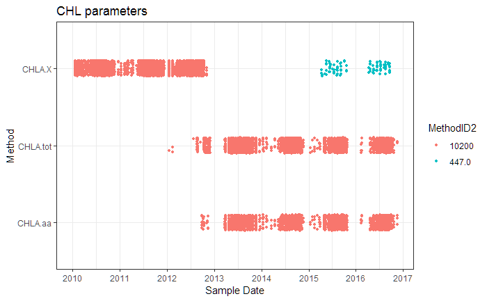

```r
CHL1016_02 %>%
  filter(!MethodID2 %in% c("10300C", "10300")) %>%
  filter(PARAM.X %in% c("CHL.tot", "CHLA", "CHLA.tot", "CHLA.X", "CHLA.aa")) %>%
  ggplot(.,
         aes(y=Sample.Date,
             x=factor(PARAM.X),
             col=MethodID2)) + theme_bw() +
  geom_point(na.rm=T,
             position=position_jitter(width=0.1), size=1) +
  xlab("Method") + ylab("Sample Date") +
  scale_y_date(date_labels ="%Y",
               date_breaks="1 year",
               limits=c(as.Date("2010-01-01"), NA)) +
  coord_flip() +
  ggtitle("CHL parameters")
```

```r
# By year
CHL1016_02 %>%
  mutate(Samp_YR = lubridate::year(Sample.Date)) %>%
  group_by(PARAM.X, Proj.Grp, Samp_YR) %>%
  filter(PARAM.X %in% c("CHL.tot", "CHLA", "CHLA.tot", "CHLA.X", "CHLA.aa")) %>%
  filter(!MethodID2 %in% c("10300C","10300", "447.0")) %>%
  summarise(.,
            n_obs=n(),
            n_NonDet=sum(stringr::str_detect(Non_Detect, "U"), na.rm=T)) %>%
  mutate(p_NonDetect = sprintf("%.f%%", (n_NonDet/n_obs)*100)) %>%
  select(Proj.Grp, PARAM.X, Samp_YR, p_NonDetect) %>%
  spread(Samp_YR, p_NonDetect, drop=F) %>%
  htmlTable::htmlTable(., css.cell = rbind(rep("padding-left: 0.75em; padding-right: 0.75em;font-size: 0.75em;", times=ncol(.)+1), matrix("padding-left: 0.75em; padding-right: 0.75em; font-size: 0.75em;", ncol=ncol(.)+1, nrow=nrow(.))), align=c("rll|c|ccc|cccc|c"), caption="", total=F, n.tspanner=rep(3,length(unique(.$Proj.Grp))), tspanner=rep("",length(unique(.$Proj.Grp))))
```

|  | Proj.Grp | PARAM.X | 2010 | 2011 | 2012 | 2013 | 2014 | 2015 | 2016 |
| --- | --- | --- | --- | --- | --- | --- | --- | --- | --- |
| 1 | BOR | CHLA.aa |  |  | 0% | 76% | 88% | 67% | 78% |
| 2 | BOR | CHLA.tot |  |  | 0% | 71% | 12% | 22% | 0% |
| 3 | BOR | CHLA.X | 9% | 100% | 27% |  |  |  |  |
| 4 | BRI | CHLA.aa |  |  |  |  | 99% | 89% |  |
| 5 | BRI | CHLA.tot |  |  |  |  | 61% | 60% |  |
| 6 | BRI | CHLA.X |  |  |  |  |  |  |  |
| 7 | CUWJ | CHLA.aa |  |  |  |  |  |  |  |
| 8 | CUWJ | CHLA.tot |  |  |  |  |  |  |  |
| 9 | CUWJ | CHLA.X | 5% | 4% | 0% |  |  |  |  |
| 10 | FarmB | CHLA.aa |  |  |  |  |  |  | 0% |
| 11 | FarmB | CHLA.tot |  |  |  |  |  |  | 0% |
| 12 | FarmB | CHLA.X |  |  |  |  |  |  |  |
| 13 | FRNG | CHLA.aa |  |  |  | 73% |  | 61% |  |
| 14 | FRNG | CHLA.tot |  |  |  | 43% |  | 24% |  |
| 15 | FRNG | CHLA.X |  |  |  |  |  |  |  |
| 16 | GSLWET | CHLA.aa |  |  |  |  |  |  |  |
| 17 | GSLWET | CHLA.tot |  |  |  |  |  |  |  |
| 18 | GSLWET | CHLA.X | 3% | 26% |  |  |  |  |  |
| 19 | HAB | CHLA.aa |  |  |  |  |  |  | 13% |
| 20 | HAB | CHLA.tot |  |  |  |  |  |  | 3% |
| 21 | HAB | CHLA.X |  |  |  |  |  |  |  |
| 22 | IW | CHLA.aa |  |  |  |  |  |  |  |
| 23 | IW | CHLA.tot |  |  | 0% |  |  |  |  |
| 24 | IW | CHLA.X |  |  | 37% |  |  |  |  |
| 25 | JRULI | CHLA.aa |  |  |  |  |  |  |  |
| 26 | JRULI | CHLA.tot |  |  | 100% |  |  |  |  |
| 27 | JRULI | CHLA.X | 3% | 29% | 27% |  |  |  |  |
| 28 | LAKES | CHLA.aa |  |  | 0% | 81% | 73% | 84% | 66% |
| 29 | LAKES | CHLA.tot |  |  |  | 59% | 43% | 64% | 44% |
| 30 | LAKES | CHLA.X | 18% | 25% | 48% |  |  |  |  |
| 31 | NPS | CHLA.aa |  |  |  | 0% |  |  |  |
| 32 | NPS | CHLA.tot |  |  |  | 0% |  |  |  |
| 33 | NPS | CHLA.X |  |  |  |  |  |  |  |
| 34 | REFWET | CHLA.aa |  |  |  |  | 100% | 94% |  |
| 35 | REFWET | CHLA.tot |  |  |  |  | 88% | 71% |  |
| 36 | REFWET | CHLA.X |  |  |  |  |  |  |  |
| 37 | SBCI | CHLA.aa |  |  |  | 100% | 90% |  |  |
| 38 | SBCI | CHLA.tot |  |  |  | 92% | 59% |  |  |
| 39 | SBCI | CHLA.X |  |  |  |  |  |  |  |
| 40 | TMDLLAKES | CHLA.aa |  |  | 0% |  | 82% | 88% |  |
| 41 | TMDLLAKES | CHLA.tot |  |  |  |  | 57% | 41% |  |
| 42 | TMDLLAKES | CHLA.X | 0% | 25% | 33% |  |  |  |  |
| 43 | UBI | CHLA.aa |  |  |  |  |  |  |  |
| 44 | UBI | CHLA.tot |  |  |  |  |  |  |  |
| 45 | UBI | CHLA.X | 0% |  |  |  |  |  |  |
| 46 | UCASE | CHLA.aa |  |  | 11% | 54% | 70% | 55% | 49% |
| 47 | UCASE | CHLA.tot |  |  | 0% | 52% | 52% | 38% | 21% |
| 48 | UCASE | CHLA.X | 0% | 13% | 9% |  |  |  |  |
| 49 | unknown | CHLA.aa |  |  |  | 73% |  | 33% | 0% |
| 50 | unknown | CHLA.tot |  |  |  | 53% |  | 33% | 0% |
| 51 | unknown | CHLA.X | 0% | 75% | 0% |  |  |  |  |
| 52 | USFS | CHLA.aa |  |  |  |  |  |  |  |
| 53 | USFS | CHLA.tot |  |  |  |  |  |  |  |
| 54 | USFS | CHLA.X | 11% |  |  |  |  |  |  |
| 55 | UtahLK | CHLA.aa |  |  |  |  | 50% |  | 0% |
| 56 | UtahLK | CHLA.tot |  |  |  |  | 0% |  | 0% |
| 57 | UtahLK | CHLA.X |  | 0% | 22% |  |  |  |  |
| 58 | WINTERLAKES | CHLA.aa |  |  |  |  |  |  |  |
| 59 | WINTERLAKES | CHLA.tot |  |  |  |  |  |  |  |
| 60 | WINTERLAKES | CHLA.X | 6% | 0% | 0% |  |  |  |  |
| 61 | WLA | CHLA.aa |  |  |  | 100% | 79% | 100% |  |
| 62 | WLA | CHLA.tot |  |  |  | 74% | 42% | 88% |  |
| 63 | WLA | CHLA.X |  | 0% | 28% |  |  |  |  |
| 64 | WRI | CHLA.aa |  |  |  |  |  |  | 70% |
| 65 | WRI | CHLA.tot |  |  |  |  |  |  | 42% |
| 66 | WRI | CHLA.X |  |  |  |  |  |  |  |
| 67 | WSpur | CHLA.aa |  |  |  | 78% |  | 100% | 100% |
| 68 | WSpur | CHLA.tot |  |  | 16% | 54% |  | 75% | 75% |
| 69 | WSpur | CHLA.X | 0% | 12% | 20% |  |  |  |  |
| 70 | WWTP | CHLA.aa |  |  |  |  |  |  |  |
| 71 | WWTP | CHLA.tot |  |  | 20% |  |  |  |  |
| 72 | WWTP | CHLA.X | 4% | 17% | 30% |  |  |  |  |

[output not shown]

[output cut: 41 more lines]

```r
# Ignore Project-Grps, look at CHL data as a whole
# CHLA records :: Percent of records w/ NonDetect by PARAM
CHL1016_02 %>% mutate(
  Samp_WYqtr = case_when(
    lubridate::month(.$Sample.Date) > 9 ~
      paste(lubridate::year(.$Sample.Date)+1, ".q",
            sprintf("%.2i", lubridate::quarter(.$Sample.Date, with_year = F,
                                               fiscal_start = 10)), sep=""),
    TRUE ~ paste(lubridate::year(.$Sample.Date),".q",
                 sprintf("%.2i",lubridate::quarter(.$Sample.Date, with_year=F,
                                                   fiscal_start=10)),sep=""))) %>%
  filter(PARAM.X %in% c("CHL.tot", "CHLA", "CHLA.tot", "CHLA.X", "CHLA.aa")) %>%
  filter(!MethodID2 %in% c("10300C","10300", "447.0")) %>%
  distinct(SK2_3, PARAM.X, .keep_all = T) %>%
  group_by(Samp_WYqtr, PARAM.X) %>%
  summarise(.,
            n_obs=n(),
            n_NonDet=sum(stringr::str_detect(Non_Detect, "U"), na.rm=T)) %>%
  mutate(p_NonDetect = sprintf("%.f%%", (n_NonDet/n_obs)*100)) %>%
  select(PARAM.X, Samp_WYqtr, p_NonDetect) %>%
  spread(PARAM.X, p_NonDetect) %>%
  htmlTable::htmlTable(., css.cell = rbind(rep("padding-left: 0.75em; padding-right: 0.75em;font-size: 0.75em;", times=ncol(.)+1), matrix("padding-left: 0.75em; padding-right: 0.75em; font-size: 0.75em;", ncol=ncol(.)+1, nrow=nrow(.))), align=c("rll|c|ccc|cccc|c"), caption="", total=F)
```

|  | Samp_WYqtr | CHLA.aa | CHLA.tot | CHLA.X |
| --- | --- | --- | --- | --- |
| 1 | 2010.q02 |  |  | 3% |
| 2 | 2010.q03 |  |  | 3% |
| 3 | 2010.q04 |  |  | 4% |
| 4 | 2011.q01 |  |  | 9% |
| 5 | 2011.q02 |  |  | 16% |
| 6 | 2011.q03 |  |  | 28% |
| 7 | 2011.q04 |  |  | 15% |
| 8 | 2012.q01 |  |  | 29% |
| 9 | 2012.q02 |  | 100% | 21% |
| 10 | 2012.q03 |  |  | 28% |
| 11 | 2012.q04 | 0% | 17% | 27% |
| 12 | 2013.q01 | 4% | 13% | 23% |
| 13 | 2013.q02 | 71% | 26% |  |
| 14 | 2013.q03 | 79% | 58% |  |
| 15 | 2013.q04 | 71% | 57% |  |
| 16 | 2014.q01 | 80% | 59% |  |
| 17 | 2014.q02 | 100% | 94% |  |
| 18 | 2014.q03 | 82% | 53% |  |
| 19 | 2014.q04 | 81% | 50% |  |
| 20 | 2015.q01 | 84% | 51% |  |
| 21 | 2015.q02 | 88% | 41% |  |
| 22 | 2015.q03 | 87% | 58% |  |
| 23 | 2015.q04 | 79% | 54% |  |
| 24 | 2016.q01 | 49% | 22% |  |
| 25 | 2016.q02 | 100% | 67% |  |
| 26 | 2016.q03 | 85% | 61% |  |
| 27 | 2016.q04 | 47% | 20% |  |
| 28 | 2017.q01 | 22% | 6% |  |

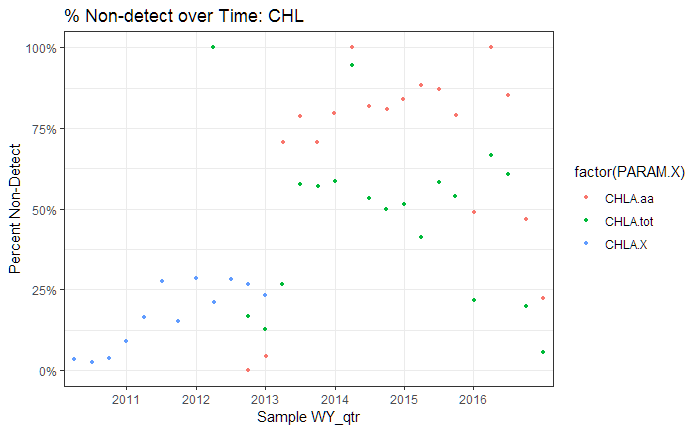

```r
CHL1016_02 %>% mutate(
  Samp_WYqtr = case_when(
    lubridate::month(.$Sample.Date) > 9 ~
      paste(lubridate::year(.$Sample.Date)+1, ".q",
            sprintf("%.2i", lubridate::quarter(.$Sample.Date, with_year = F,
                                               fiscal_start = 10)), sep=""),
    TRUE ~ paste(lubridate::year(.$Sample.Date),".q",
                 sprintf("%.2i",lubridate::quarter(.$Sample.Date, with_year=F,
                                                   fiscal_start=10)),sep=""))) %>%
  filter(PARAM.X %in% c("CHL.tot", "CHLA", "CHLA.tot", "CHLA.X", "CHLA.aa")) %>%
  filter(!MethodID2 %in% c("10300C","10300", "447.0")) %>%
  distinct(SK2_3, PARAM.X, .keep_all = T) %>%
  group_by(Samp_WYqtr, PARAM.X) %>%
  summarise(.,
            n_obs=n(),
            n_NonDet=sum(stringr::str_detect(Non_Detect, "U"), na.rm=T)) %>%
  mutate(p_NonDetect = (n_NonDet/n_obs)*100) %>%
  select(PARAM.X, Samp_WYqtr, p_NonDetect) %>%
  ggplot(.,
         aes(y=p_NonDetect,
             x=(Samp_WYqtr),
             col=factor(PARAM.X))) + theme_bw() +
  geom_point(na.rm=T,
             position=position_jitter(width=0.05), size=1) +
  scale_y_continuous(labels = scales::percent_format(accuracy = 1, scale = 1.0)) +
  scale_x_discrete(labels = c("2011.q01" = "2011",
                              "2012.q01" = "2012",
                              "2013.q01" = "2013",
                              "2014.q01" = "2014",
                              "2015.q01" = "2015",
                              "2016.q01" = "2016"),
                   breaks=c("2011.q01","2012.q01", "2013.q01","2014.q01", "2015.q01", "2016.q01")) +
  xlab("Sample WY_qtr") + ylab("Percent Non-Detect") +
  ggtitle("% Non-detect over Time: CHL")
```

### 5.3 Plot % Non-detects both datasets…

```r
CHL1718_02 %>% mutate(
  Samp_WYqtr = case_when(
    lubridate::month(.$SDate_x) > 9 ~
      paste(lubridate::year(.$SDate_x)+1, ".q",
            sprintf("%.2i", lubridate::quarter(.$SDate_x, with_year = F,
                                               fiscal_start = 10)), sep=""),
    TRUE ~ paste(lubridate::year(.$SDate_x),".q",
                 sprintf("%.2i",lubridate::quarter(.$SDate_x, with_year=F,
                                                   fiscal_start=10)),sep=""))) %>%
  group_by(Method.GRP, ParamX, Samp_WYqtr) %>%
  # filter(stringr::str_detect(Method.ID, "HPLC",)) %>%
  filter(ParamX %in% c("CHLA", "CHL.tot")) %>%
  summarise(.,
            n_obs=n(),
            n_NonDet=sum(stringr::str_detect(R.Code, "U"), na.rm=T)) %>%
  mutate(p_NonDetect = (n_NonDet/n_obs)*100) %>%
  select(Param=ParamX, Method=Method.GRP, Samp_WYqtr, p_NonDetect) -> CHL1718_param.Date
```

```r
CHL1016_02 %>% mutate(
  Samp_WYqtr = case_when(
    lubridate::month(.$Sample.Date) > 9 ~
      paste(lubridate::year(.$Sample.Date)+1, ".q",
            sprintf("%.2i", lubridate::quarter(.$Sample.Date, with_year = F,
                                               fiscal_start = 10)), sep=""),
    TRUE ~ paste(lubridate::year(.$Sample.Date),".q",
                 sprintf("%.2i",lubridate::quarter(.$Sample.Date, with_year=F,
                                                   fiscal_start=10)),sep=""))) %>%
  filter(PARAM.X %in% c("CHL.tot", "CHLA", "CHLA.tot", "CHLA.X", "CHLA.aa")) %>%
  filter(!MethodID2 %in% c("10300C","10300", "447.0")) %>%
  distinct(SK2_3, PARAM.X, .keep_all = T) %>%
  group_by(Samp_WYqtr, MethodID2, PARAM.X) %>%
  summarise(.,
            n_obs=n(),
            n_NonDet=sum(stringr::str_detect(Non_Detect, "U"), na.rm=T)) %>%
  mutate(p_NonDetect = (n_NonDet/n_obs)*100) %>%
  select(Param=PARAM.X, Method=MethodID2, Samp_WYqtr, p_NonDetect) -> CHL1016_param.Date
```

```r
bind_rows(CHL1016_param.Date, CHL1718_param.Date) -> CHL_param.Date
```

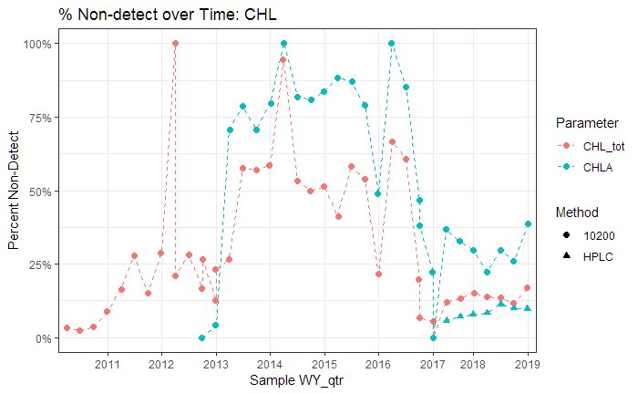

```r
CHL_param.Date %>% ungroup() %>%
  mutate(
    Param = recode(Param,
                   "CHL.tot" = "CHL_tot",
                   "CHLA.tot" = "CHL_tot",
                   "CHLA.aa" = "CHLA",
                   "CHLA.X" = "CHL_tot"),
    Method = recode(Method,
                    "CHL" = "10200",
                    "CHL_hplc" = "HPLC")) %>%
  arrange(Param, Method, Samp_WYqtr) %>%
  ggplot(.,
         aes(y=p_NonDetect,
             x=(Samp_WYqtr),
             col=factor(Param), group=interaction(.$Param, .$Method),
             shape=Method)) + theme_bw() +
  geom_point(na.rm=T,
             position=position_jitter(width=0.05), size=2) +
  scale_y_continuous(labels = scales::percent_format(accuracy = 1, scale = 1.0)) +
  scale_x_discrete(labels = c("2011.q01" = "2011",
                              "2012.q01" = "2012",
                              "2013.q01" = "2013",
                              "2014.q01" = "2014",
                              "2015.q01" = "2015",
                              "2016.q01" = "2016",
                              "2017.q01" = "2017",
                              "2018.q01" = "2018",
                              "2019.q01" = "2019"),
                   breaks=c("2011.q01","2012.q01", "2013.q01","2014.q01", "2015.q01", "2016.q01",
                            "2017.q01", "2018.q01", "2019.q01")) +
  xlab("Sample WY_qtr") + ylab("Percent Non-Detect") + labs(col="Parameter") +
  ggtitle("% Non-detect over Time: CHL") +
  geom_path(na.rm=T, lty=2)
```

- print version…

```r
(
  CHL_param.Date %>% ungroup() %>%
    mutate(
      Param = recode(Param,
                     "CHL.tot" = "CHL_tot",
                     "CHLA.tot" = "CHL_tot",
                     "CHLA.aa" = "CHLA",
                     "CHLA.X" = "CHL_tot"),
      Method = recode(Method,
                      "CHL" = "10200",
                      "CHL_hplc" = "HPLC")) %>%
    arrange(Param, Method, Samp_WYqtr) %>%
    ggplot(.,
           aes(y=p_NonDetect,
               x=(Samp_WYqtr),
               col=factor(Param), group=interaction(.$Param, .$Method),
               shape=Method)) + theme_bw() +
    geom_point(na.rm=T,
               position=position_jitter(width=0.05), size=2) +
    scale_y_continuous(labels = scales::percent_format(accuracy = 1, scale = 1.0)) +
    scale_x_discrete(labels = c("2011.q01" = "2011",
                                "2012.q01" = "2012",
                                "2013.q01" = "2013",
                                "2014.q01" = "2014",
                                "2015.q01" = "2015",
                                "2016.q01" = "2016",
                                "2017.q01" = "2017",
                                "2018.q01" = "2018",
                                "2019.q01" = "2019"),
                     breaks=c("2011.q01","2012.q01", "2013.q01","2014.q01", "2015.q01", "2016.q01",
                              "2017.q01", "2018.q01", "2019.q01")) +
    xlab("Sample WY_qtr") + ylab("Percent Non-Detect") + labs(col="Parameter") +
    ggtitle("% Non-detect over Time: CHL") +
    geom_path(na.rm=T, lty=2)
) %>% ggsave("state_CHL_20102018_p_nonDetect_paramMethod.jpg", .,
             height=5, width=8, dpi=500)
```

## XX.0 Project-based CHL data review(s)

XX.1 Willard Spur + Working DFs:

- 2010-2016 :: `CHL1016_01` [has been updated since writing…]
- 2016-2018 LL `CHL1718_02` [as of 190715]
  - *Includes annotation re: imported* (for utah lake)
- See: “CHL_Status_ALL_03_190417_v01.nb.html” and notebook

## END

```r
lastwork.date <- format(Sys.Date(), "%y%m%d")
```

**Start work date ::** 190417  
**Last work date ::** 190814  
**Current review date ::** 190815

eof